# R Notebook - practica Final

Activitat 2 Hauràs de presentar un anàlisis de classificació supervisada o de clustering fet amb R. Ha d’incloure : 1-Comentaris sobre les dades, 2-Estudi previ a l’anàlisi (transformacions, gràfics) 3-Model.Justificar perquè s’ha triat el model escollit i amb quins paràmetres s’aplica 4-Finalment valorar quin és el resultat obtingut.

Estudi de dades de reserves d hotels per poder predir les cancelacions [src](https://www.kaggle.com/code/achalsuresh/analysis-on-hotel-booking-data-using-r/notebook)

```r
# Instalació de paquets necesaris
if(!require('ISLR')) {
  install.packages('ISLR')
}
library(ISLR)       # load ISLR data package
library(tidyverse)
library(ggplot2)
library(e1071)   #library needed to use Naive Bayes algorithm, svm algorithm
library(rpart)   #Decision Tree
library(rpart.plot)
if(!require('randomForest')) {
  install.packages('randomForest')
}
library(randomForest)
library(pROC) #ROC curve for analysis
```

1-Comentaris sobre les dades

```r
#carga de les dades

hotel_data <- read_csv("C:/Users/Alumne_mati1/BigData/dat/hotel_bookings.csv")
# Observem el tipus de dades per columnes

spec(hotel_data)
```

Comentaris sobre les dades captades

dades de caracter string en el cas com de nom del hotel, paisos, etc dades de caracten numeric com nombre d’adults, nens, etc dades de caracter dates reserva No hi han boleans son valors numerics 0 o 1

2-Estudi previ a l’anàlisi (transformacions, gràfics)

Preparació de dades i explorarció

```r
hotel_data<- as_tibble(hotel_data)

glimpse(hotel_data)
```

```
Rows: 119,390
Columns: 32
$ hotel                          <chr> "Resort Hotel", "Resort Hotel", "Resort …
$ is_canceled                    <dbl> 0, 0, 0, 0, 0, 0, 0, 0, 1, 1, 1, 0, 0, 0…
$ lead_time                      <dbl> 342, 737, 7, 13, 14, 14, 0, 9, 85, 75, 2…
$ arrival_date_year              <dbl> 2015, 2015, 2015, 2015, 2015, 2015, 2015…
$ arrival_date_month             <chr> "July", "July", "July", "July", "July", …
$ arrival_date_week_number       <dbl> 27, 27, 27, 27, 27, 27, 27, 27, 27, 27, …
$ arrival_date_day_of_month      <dbl> 1, 1, 1, 1, 1, 1, 1, 1, 1, 1, 1, 1, 1, 1…
$ stays_in_weekend_nights        <dbl> 0, 0, 0, 0, 0, 0, 0, 0, 0, 0, 0, 0, 0, 0…
$ stays_in_week_nights           <dbl> 0, 0, 1, 1, 2, 2, 2, 2, 3, 3, 4, 4, 4, 4…
$ adults                         <dbl> 2, 2, 1, 1, 2, 2, 2, 2, 2, 2, 2, 2, 2, 2…
$ children                       <dbl> 0, 0, 0, 0, 0, 0, 0, 0, 0, 0, 0, 0, 0, 1…
$ babies                         <dbl> 0, 0, 0, 0, 0, 0, 0, 0, 0, 0, 0, 0, 0, 0…
$ meal                           <chr> "BB", "BB", "BB", "BB", "BB", "BB", "BB"…
```

[output cut: 19 more lines]

Tractament de columnes

```r
hotel_data<-hotel_data%>%
  mutate(
         hotel=as.factor(hotel),
         is_canceled=as.factor(is_canceled),
         meal=as.factor(meal),
         country=as.factor(country),
         market_segment=as.factor(market_segment),
         distribution_channel=as.factor(distribution_channel),
         is_repeated_guest=as.factor(is_repeated_guest),
         reserved_room_type=as.factor(reserved_room_type),
         assigned_room_type=as.factor(assigned_room_type),
         deposit_type=as.factor(deposit_type),
         customer_type=as.factor(customer_type),
         reservation_status=as.factor(reservation_status),
         agent=as.factor(agent),
         company=as.factor(company),
         arrival_date_day_of_month=as.factor(arrival_date_day_of_month),
         arrival_date_month=as.factor(arrival_date_month),
         arrival_date_year=as.factor(arrival_date_year)
         )
```

Analisis de les dades

```r
head(hotel_data)
```

| hotel | is_canceled | lead_time | arrival_date_year | arrival_date_month | arrival_date_week_number | arrival_date_day_of_month | stays_in_weekend_nights | stays_in_week_nights | adults | children | babies | meal | country | market_segment | distribution_channel | is_repeated_guest | previous_cancellations | previous_bookings_not_canceled | reserved_room_type | assigned_room_type | booking_changes | deposit_type | agent | company | days_in_waiting_list | customer_type | adr | required_car_parking_spaces | total_of_special_requests | … |
| --- | --- | --- | --- | --- | --- | --- | --- | --- | --- | --- | --- | --- | --- | --- | --- | --- | --- | --- | --- | --- | --- | --- | --- | --- | --- | --- | --- | --- | --- | --- |
| Resort Hotel | 0 | 342 | 2015 | July | 27 | 1 | 0 | 0 | 2 | 0 | 0 | BB | PRT | Direct | Direct | 0 | 0 | 0 | C | C | 3 | No Deposit | NULL | NULL | 0 | Transient | 0 | 0 | 0 | … |
| Resort Hotel | 0 | 737 | 2015 | July | 27 | 1 | 0 | 0 | 2 | 0 | 0 | BB | PRT | Direct | Direct | 0 | 0 | 0 | C | C | 4 | No Deposit | NULL | NULL | 0 | Transient | 0 | 0 | 0 | … |
| Resort Hotel | 0 | 7 | 2015 | July | 27 | 1 | 0 | 1 | 1 | 0 | 0 | BB | GBR | Direct | Direct | 0 | 0 | 0 | A | C | 0 | No Deposit | NULL | NULL | 0 | Transient | 75 | 0 | 0 | … |
| Resort Hotel | 0 | 13 | 2015 | July | 27 | 1 | 0 | 1 | 1 | 0 | 0 | BB | GBR | Corporate | Corporate | 0 | 0 | 0 | A | A | 0 | No Deposit | 304 | NULL | 0 | Transient | 75 | 0 | 0 | … |
| Resort Hotel | 0 | 14 | 2015 | July | 27 | 1 | 0 | 2 | 2 | 0 | 0 | BB | GBR | Online TA | TA/TO | 0 | 0 | 0 | A | A | 0 | No Deposit | 240 | NULL | 0 | Transient | 98 | 0 | 1 | … |
| Resort Hotel | 0 | 14 | 2015 | July | 27 | 1 | 0 | 2 | 2 | 0 | 0 | BB | GBR | Online TA | TA/TO | 0 | 0 | 0 | A | A | 0 | No Deposit | 240 | NULL | 0 | Transient | 98 | 0 | 1 | … |

```r
tail(hotel_data)
```

| hotel | is_canceled | lead_time | arrival_date_year | arrival_date_month | arrival_date_week_number | arrival_date_day_of_month | stays_in_weekend_nights | stays_in_week_nights | adults | children | babies | meal | country | market_segment | distribution_channel | is_repeated_guest | previous_cancellations | previous_bookings_not_canceled | reserved_room_type | assigned_room_type | booking_changes | deposit_type | agent | company | days_in_waiting_list | customer_type | adr | required_car_parking_spaces | total_of_special_requests | … |
| --- | --- | --- | --- | --- | --- | --- | --- | --- | --- | --- | --- | --- | --- | --- | --- | --- | --- | --- | --- | --- | --- | --- | --- | --- | --- | --- | --- | --- | --- | --- |
| City Hotel | 0 | 21 | 2017 | August | 35 | 30 | 2 | 5 | 2 | 0 | 0 | BB | BEL | Offline TA/TO | TA/TO | 0 | 0 | 0 | A | A | 0 | No Deposit | 394 | NULL | 0 | Transient | 96.14 | 0 | 2 | … |
| City Hotel | 0 | 23 | 2017 | August | 35 | 30 | 2 | 5 | 2 | 0 | 0 | BB | BEL | Offline TA/TO | TA/TO | 0 | 0 | 0 | A | A | 0 | No Deposit | 394 | NULL | 0 | Transient | 96.14 | 0 | 0 | … |
| City Hotel | 0 | 102 | 2017 | August | 35 | 31 | 2 | 5 | 3 | 0 | 0 | BB | FRA | Online TA | TA/TO | 0 | 0 | 0 | E | E | 0 | No Deposit | 9 | NULL | 0 | Transient | 225.43 | 0 | 2 | … |
| City Hotel | 0 | 34 | 2017 | August | 35 | 31 | 2 | 5 | 2 | 0 | 0 | BB | DEU | Online TA | TA/TO | 0 | 0 | 0 | D | D | 0 | No Deposit | 9 | NULL | 0 | Transient | 157.71 | 0 | 4 | … |
| City Hotel | 0 | 109 | 2017 | August | 35 | 31 | 2 | 5 | 2 | 0 | 0 | BB | GBR | Online TA | TA/TO | 0 | 0 | 0 | A | A | 0 | No Deposit | 89 | NULL | 0 | Transient | 104.40 | 0 | 0 | … |
| City Hotel | 0 | 205 | 2017 | August | 35 | 29 | 2 | 7 | 2 | 0 | 0 | HB | DEU | Online TA | TA/TO | 0 | 0 | 0 | A | A | 0 | No Deposit | 9 | NULL | 0 | Transient | 151.20 | 0 | 2 | … |

```r
summary(hotel_data)
```

```
          hotel       is_canceled   lead_time   arrival_date_year
 City Hotel  :79330   0:75166     Min.   :  0   2015:21996
 Resort Hotel:40060   1:44224     1st Qu.: 18   2016:56707
                                  Median : 69   2017:40687
                                  Mean   :104
                                  3rd Qu.:160
                                  Max.   :737

 arrival_date_month arrival_date_week_number arrival_date_day_of_month
 August :13877      Min.   : 1.00            17     : 4406
 July   :12661      1st Qu.:16.00            5      : 4317
 May    :11791      Median :28.00            15     : 4196
 October:11160      Mean   :27.17            25     : 4160
 April  :11089      3rd Qu.:38.00            26     : 4147
 June   :10939      Max.   :53.00            9      : 4096
 (Other):47873                               (Other):94068
 stays_in_weekend_nights stays_in_week_nights     adults          children
 Min.   : 0.0000         Min.   : 0.0         Min.   : 0.000   Min.   : 0.0000
 1st Qu.: 0.0000         1st Qu.: 1.0         1st Qu.: 2.000   1st Qu.: 0.0000
 Median : 1.0000         Median : 2.0         Median : 2.000   Median : 0.0000
 Mean   : 0.9276         Mean   : 2.5         Mean   : 1.856   Mean   : 0.1039
 3rd Qu.: 2.0000         3rd Qu.: 3.0         3rd Qu.: 2.000   3rd Qu.: 0.0000
 Max.   :19.0000         Max.   :50.0         Max.   :55.000   Max.   :10.0000
                                                               NA's   :4
     babies                 meal          country            market_segment
 Min.   : 0.000000   BB       :92310   PRT    :48590   Online TA    :56477
 1st Qu.: 0.000000   FB       :  798   GBR    :12129   Offline TA/TO:24219
 Median : 0.000000   HB       :14463   FRA    :10415   Groups       :19811
 Mean   : 0.007949   SC       :10650   ESP    : 8568   Direct       :12606
 3rd Qu.: 0.000000   Undefined: 1169   DEU    : 7287   Corporate    : 5295
 Max.   :10.000000                     ITA    : 3766   Complementary:  743
                                       (Other):28635   (Other)      :  239
 distribution_channel is_repeated_guest previous_cancellations
 Corporate: 6677      0:115580          Min.   : 0.00000
 Direct   :14645      1:  3810          1st Qu.: 0.00000
 GDS      :  193                        Median : 0.00000
 TA/TO    :97870                        Mean   : 0.08712
 Undefined:    5                        3rd Qu.: 0.00000
                                        Max.   :26.00000

```

[output cut: 24 more lines]

```
 required_car_parking_spaces total_of_special_requests reservation_status
 Min.   :0.00000             Min.   :0.0000            Canceled :43017
 1st Qu.:0.00000             1st Qu.:0.0000            Check-Out:75166
 Median :0.00000             Median :0.0000            No-Show  : 1207
 Mean   :0.06252             Mean   :0.5714
 3rd Qu.:0.00000             3rd Qu.:1.0000
 Max.   :8.00000             Max.   :5.0000

 reservation_status_date
 Min.   :2014-10-17
 1st Qu.:2016-02-01
 Median :2016-08-07
 Mean   :2016-07-30
 3rd Qu.:2017-02-08
 Max.   :2017-09-14
```

```r
nrow(hotel_data)    # 119390
```

```
[1] 119390
```

```r
ncol(hotel_data)    # 32
```

```
[1] 32
```

Numero de paisos que estan involucrats

```r
hotel_data%>%
  group_by(country)%>%
  summarise(num=n())%>%
  arrange(desc(num))
```

| country | num |
| --- | --- |
| PRT | 48590 |
| GBR | 12129 |
| FRA | 10415 |
| ESP | 8568 |
| DEU | 7287 |
| ITA | 3766 |
| IRL | 3375 |
| BEL | 2342 |
| BRA | 2224 |
| NLD | 2104 |

[output cut: 168 more lines]

Comprovació dels outliers

```r
hotel_data%>%
  filter(adr>1000)
```

| hotel | is_canceled | lead_time | arrival_date_year | arrival_date_month | arrival_date_week_number | arrival_date_day_of_month | stays_in_weekend_nights | stays_in_week_nights | adults | children | babies | meal | country | market_segment | distribution_channel | is_repeated_guest | previous_cancellations | previous_bookings_not_canceled | reserved_room_type | assigned_room_type | booking_changes | deposit_type | agent | company | days_in_waiting_list | customer_type | adr | required_car_parking_spaces | total_of_special_requests | … |
| --- | --- | --- | --- | --- | --- | --- | --- | --- | --- | --- | --- | --- | --- | --- | --- | --- | --- | --- | --- | --- | --- | --- | --- | --- | --- | --- | --- | --- | --- | --- |
| City Hotel | 1 | 35 | 2016 | March | 13 | 25 | 0 | 1 | 2 | 0 | 0 | BB | PRT | Offline TA/TO | TA/TO | 0 | 0 | 0 | A | A | 1 | Non Refund | 12 | NULL | 0 | Transient | 5400 | 0 | 0 | … |

Degut a que nomes hi ha un valor extrany numeric i per sobre del filtre indicat el substituirem per la mitjana per no perdre completament la entrada

```r
hotel_data = hotel_data%>%
  mutate(adr = replace(adr, adr>1000, mean(adr)))
```

Creació de columnes per calcular el numero de dies d’estada i cost total

```r
hotel_data <- hotel_data %>%
  mutate(stay_nights_total = stays_in_weekend_nights + stays_in_week_nights,
       stay_cost_total = adr * stay_nights_total)

summary(hotel_data$stay_nights_total)
```

```
   Min. 1st Qu.  Median    Mean 3rd Qu.    Max.
  0.000   2.000   3.000   3.428   4.000  69.000
```

```r
summary(hotel_data$stay_cost_total)
```

```
   Min. 1st Qu.  Median    Mean 3rd Qu.    Max.
  -63.8   146.0   267.0   357.8   446.2  7590.0
```

Visualització de Dades

Diagrama de punts amb el numero de nits /cost total

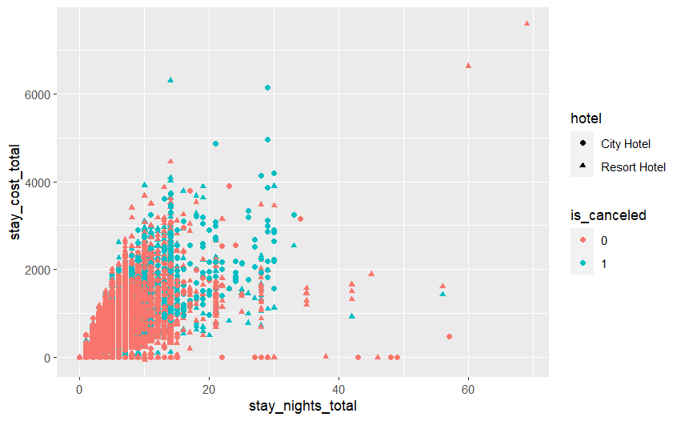

```r
ggplot(hotel_data, aes(x=stay_nights_total,y=stay_cost_total,shape=hotel,color=is_canceled))+
  geom_point(alpha=1)
```

Exploració de les dades a traves de diferents segments del mercat

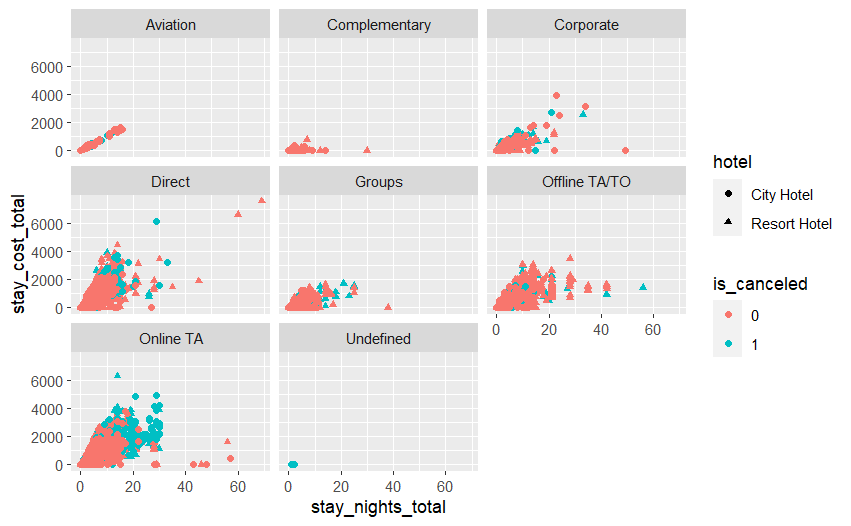

```r
ggplot(hotel_data, aes(x=stay_nights_total,y=stay_cost_total,shape=hotel,color=is_canceled))+
  geom_point()+
  facet_wrap(~market_segment)
```

En aquesta gràfica podem observar que en l’any 2016 va ser un dels anys amb més resereves i cancelacions

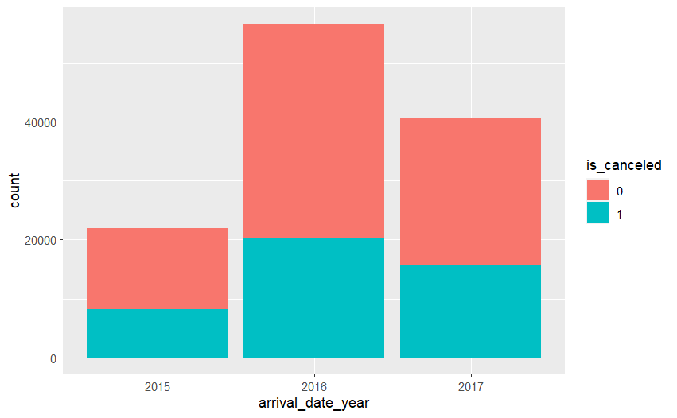

```r
hotel_data%>%
  ggplot(aes(x=arrival_date_year,fill=is_canceled))+
  geom_bar()
```

Gràfica per tipus d’hotels

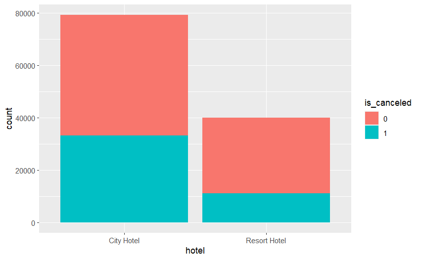

```r
hotel_data%>%
  ggplot(aes(x=hotel,fill=is_canceled))+
  geom_bar()
```

Per Asignació d’ habitació

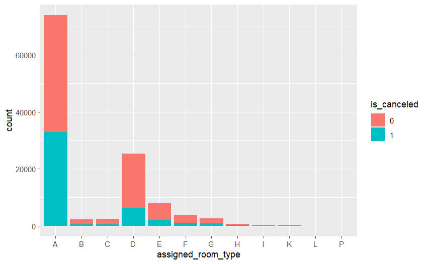

```r
hotel_data%>%
  ggplot(aes(x=assigned_room_type,fill=is_canceled))+
  geom_bar()
```

Medi de distribució

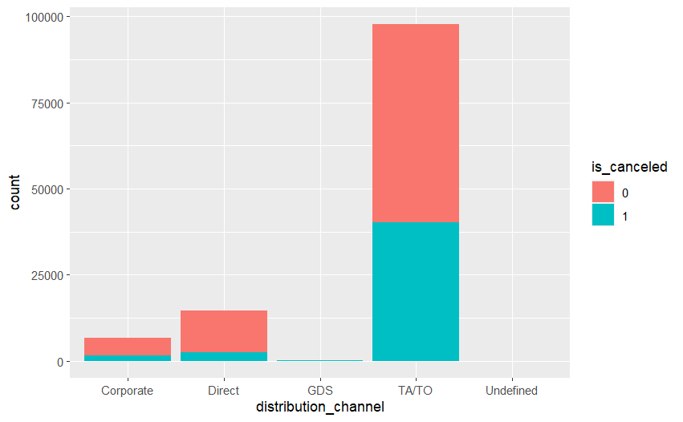

```r
hotel_data%>%
  ggplot(aes(x=distribution_channel,fill=is_canceled))+
  geom_bar()
```

Histograma dels dies en llista de espera

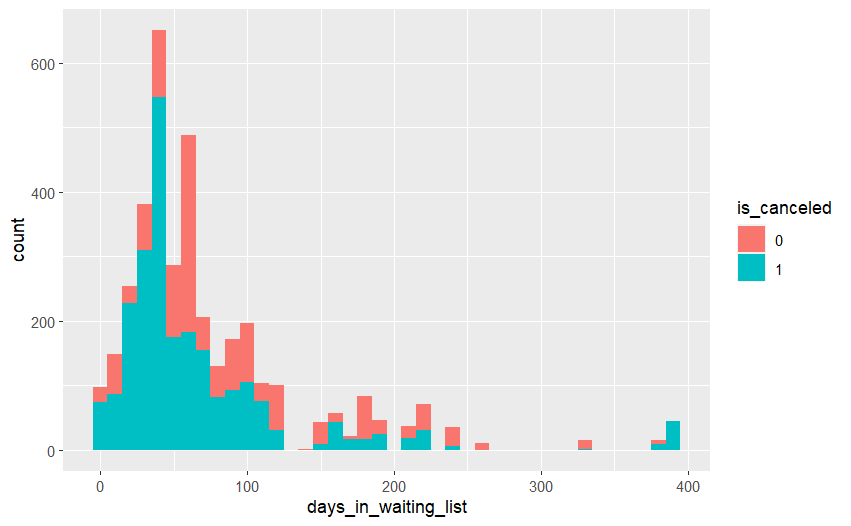

```r
hotel_data%>%
  filter(days_in_waiting_list>1)%>%
  ggplot(aes(x=days_in_waiting_list,fill=is_canceled))+
  geom_histogram(binwidth = 10)
```

gràfica per diposit

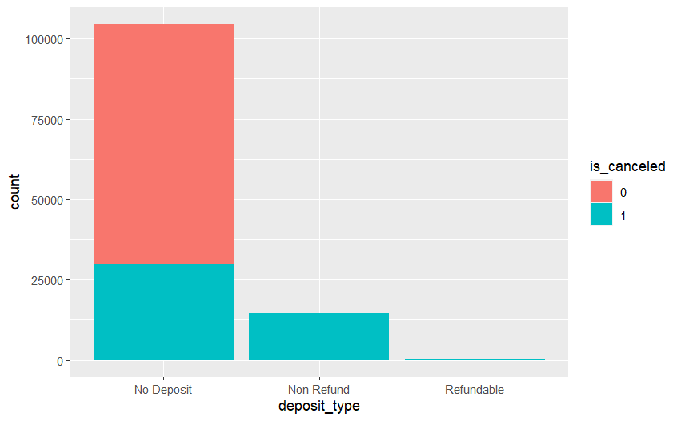

```r
hotel_data%>%
  ggplot(aes(x=deposit_type,fill=is_canceled))+
  geom_bar()
```

Cancelacions en temps de espera

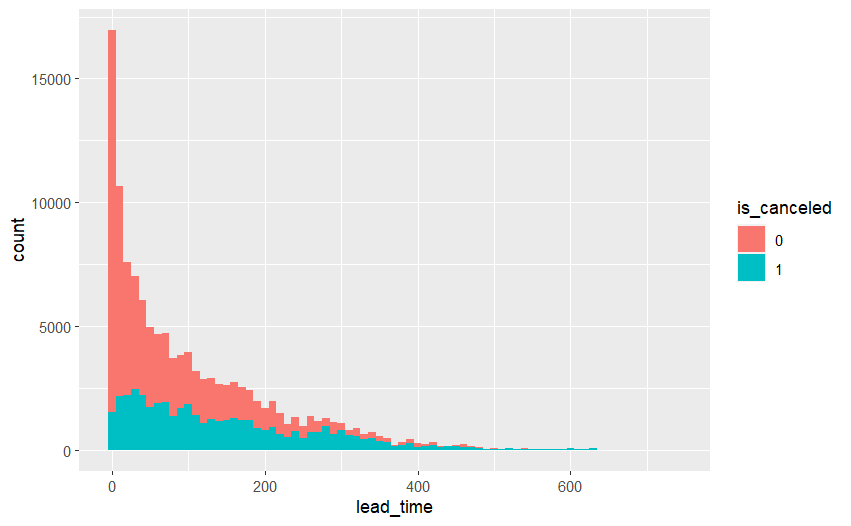

```r
hotel_data%>%
  ggplot(aes(x=lead_time,fill=is_canceled))+
  geom_histogram(binwidth=10,position="stack")
```

3-Model

Data Modeling

```r
set.seed(1)   # set a random seed
index <- sample(nrow(hotel_data), nrow(hotel_data)*0.3)

hotel_data <- hotel_data %>%
              filter(market_segment!='Undefined')

test <- hotel_data[index,]       # test set
training <-hotel_data[-index,]   # training set
```

```r
training
```

| hotel | is_canceled | lead_time | arrival_date_year | arrival_date_month | arrival_date_week_number | arrival_date_day_of_month | stays_in_weekend_nights | stays_in_week_nights | adults | children | babies | meal | country | market_segment | distribution_channel | is_repeated_guest | previous_cancellations | previous_bookings_not_canceled | reserved_room_type | assigned_room_type | booking_changes | deposit_type | agent | company | days_in_waiting_list | customer_type | adr | required_car_parking_spaces | total_of_special_requests | … |
| --- | --- | --- | --- | --- | --- | --- | --- | --- | --- | --- | --- | --- | --- | --- | --- | --- | --- | --- | --- | --- | --- | --- | --- | --- | --- | --- | --- | --- | --- | --- |
| Resort Hotel | 0 | 737 | 2015 | July | 27 | 1 | 0 | 0 | 2 | 0 | 0 | BB | PRT | Direct | Direct | 0 | 0 | 0 | C | C | 4 | No Deposit | NULL | NULL | 0 | Transient | 0.00 | 0 | 0 | … |
| Resort Hotel | 0 | 7 | 2015 | July | 27 | 1 | 0 | 1 | 1 | 0 | 0 | BB | GBR | Direct | Direct | 0 | 0 | 0 | A | C | 0 | No Deposit | NULL | NULL | 0 | Transient | 75.00 | 0 | 0 | … |
| Resort Hotel | 0 | 13 | 2015 | July | 27 | 1 | 0 | 1 | 1 | 0 | 0 | BB | GBR | Corporate | Corporate | 0 | 0 | 0 | A | A | 0 | No Deposit | 304 | NULL | 0 | Transient | 75.00 | 0 | 0 | … |
| Resort Hotel | 0 | 14 | 2015 | July | 27 | 1 | 0 | 2 | 2 | 0 | 0 | BB | GBR | Online TA | TA/TO | 0 | 0 | 0 | A | A | 0 | No Deposit | 240 | NULL | 0 | Transient | 98.00 | 0 | 1 | … |
| Resort Hotel | 0 | 14 | 2015 | July | 27 | 1 | 0 | 2 | 2 | 0 | 0 | BB | GBR | Online TA | TA/TO | 0 | 0 | 0 | A | A | 0 | No Deposit | 240 | NULL | 0 | Transient | 98.00 | 0 | 1 | … |
| Resort Hotel | 1 | 85 | 2015 | July | 27 | 1 | 0 | 3 | 2 | 0 | 0 | BB | PRT | Online TA | TA/TO | 0 | 0 | 0 | A | A | 0 | No Deposit | 240 | NULL | 0 | Transient | 82.00 | 0 | 1 | … |
| Resort Hotel | 1 | 75 | 2015 | July | 27 | 1 | 0 | 3 | 2 | 0 | 0 | HB | PRT | Offline TA/TO | TA/TO | 0 | 0 | 0 | D | D | 0 | No Deposit | 15 | NULL | 0 | Transient | 105.50 | 0 | 0 | … |
| Resort Hotel | 1 | 23 | 2015 | July | 27 | 1 | 0 | 4 | 2 | 0 | 0 | BB | PRT | Online TA | TA/TO | 0 | 0 | 0 | E | E | 0 | No Deposit | 240 | NULL | 0 | Transient | 123.00 | 0 | 0 | … |
| Resort Hotel | 0 | 35 | 2015 | July | 27 | 1 | 0 | 4 | 2 | 0 | 0 | HB | PRT | Online TA | TA/TO | 0 | 0 | 0 | D | D | 0 | No Deposit | 240 | NULL | 0 | Transient | 145.00 | 0 | 0 | … |
| Resort Hotel | 0 | 18 | 2015 | July | 27 | 1 | 0 | 4 | 2 | 1 | 0 | HB | ESP | Online TA | TA/TO | 0 | 0 | 0 | G | G | 1 | No Deposit | 241 | NULL | 0 | Transient | 154.77 | 0 | 1 | … |

[output cut: 990 more lines]

```r
test
```

| hotel | is_canceled | lead_time | arrival_date_year | arrival_date_month | arrival_date_week_number | arrival_date_day_of_month | stays_in_weekend_nights | stays_in_week_nights | adults | children | babies | meal | country | market_segment | distribution_channel | is_repeated_guest | previous_cancellations | previous_bookings_not_canceled | reserved_room_type | assigned_room_type | booking_changes | deposit_type | agent | company | days_in_waiting_list | customer_type | adr | required_car_parking_spaces | total_of_special_requests | … |
| --- | --- | --- | --- | --- | --- | --- | --- | --- | --- | --- | --- | --- | --- | --- | --- | --- | --- | --- | --- | --- | --- | --- | --- | --- | --- | --- | --- | --- | --- | --- |
| Resort Hotel | 0 | 108 | 2016 | May | 20 | 14 | 2 | 3 | 2 | 0 | 0 | HB | ESP | Direct | Direct | 0 | 0 | 0 | D | D | 1 | No Deposit | 250 | NULL | 0 | Transient | 97.20 | 1 | 1 | … |
| City Hotel | 1 | 189 | 2016 | October | 44 | 28 | 1 | 2 | 2 | 0 | 0 | BB | AUT | Online TA | TA/TO | 0 | 0 | 0 | D | D | 0 | No Deposit | 9 | NULL | 0 | Transient | 109.80 | 0 | 0 | … |
| City Hotel | 0 | 0 | 2015 | September | 38 | 18 | 0 | 1 | 2 | 0 | 0 | SC | PRT | Online TA | TA/TO | 0 | 0 | 0 | D | D | 1 | No Deposit | 9 | NULL | 0 | Contract | 115.00 | 0 | 2 | … |
| City Hotel | 1 | 212 | 2017 | June | 22 | 2 | 1 | 2 | 2 | 0 | 0 | BB | PRT | Groups | TA/TO | 0 | 0 | 0 | A | A | 0 | No Deposit | 20 | NULL | 0 | Transient-Party | 105.00 | 0 | 0 | … |
| Resort Hotel | 1 | 43 | 2017 | May | 20 | 18 | 0 | 1 | 2 | 2 | 0 | BB | ZAF | Online TA | TA/TO | 0 | 0 | 0 | G | G | 0 | No Deposit | 240 | NULL | 0 | Transient | 169.00 | 0 | 0 | … |
| Resort Hotel | 0 | 26 | 2016 | June | 25 | 12 | 2 | 3 | 2 | 0 | 0 | BB | ESP | Online TA | TA/TO | 0 | 0 | 0 | A | A | 0 | No Deposit | 240 | NULL | 0 | Transient | 129.00 | 1 | 0 | … |
| Resort Hotel | 0 | 1 | 2017 | January | 4 | 27 | 1 | 2 | 1 | 0 | 0 | BB | IRL | Direct | Direct | 0 | 0 | 0 | E | E | 0 | No Deposit | 250 | NULL | 0 | Transient-Party | 70.33 | 0 | 1 | … |
| City Hotel | 0 | 167 | 2017 | July | 29 | 19 | 0 | 2 | 2 | 1 | 0 | BB | ARG | Online TA | TA/TO | 0 | 0 | 0 | A | A | 0 | No Deposit | 9 | NULL | 0 | Transient | 125.10 | 0 | 3 | … |
| Resort Hotel | 0 | 2 | 2016 | November | 46 | 9 | 0 | 1 | 1 | 0 | 0 | BB | PRT | Corporate | Corporate | 0 | 1 | 8 | A | H | 0 | No Deposit | NULL | 81 | 0 | Transient | 33.00 | 1 | 2 | … |
| Resort Hotel | 1 | 60 | 2016 | September | 39 | 19 | 1 | 2 | 2 | 0 | 0 | BB | TUR | Online TA | TA/TO | 0 | 0 | 0 | E | E | 0 | No Deposit | 240 | NULL | 0 | Transient | 112.33 | 0 | 0 | … |

[output cut: 990 more lines]

```r
training_1 <- training[c('hotel','is_canceled','lead_time','adults','children','babies','meal',
                         'market_segment','distribution_channel','is_repeated_guest',
                         'previous_cancellations','previous_bookings_not_canceled','reserved_room_type',
                         'deposit_type','days_in_waiting_list','customer_type','adr',
                         'required_car_parking_spaces','stay_nights_total','stay_cost_total')]



logit_training_model<-glm(is_canceled~.,family="binomial",data=training_1)
summary(logit_training_model)
```

```
Call:
glm(formula = is_canceled ~ ., family = "binomial", data = training_1)

Coefficients:
                                 Estimate Std. Error z value Pr(>|z|)
(Intercept)                    -2.562e+00  2.081e-01 -12.314  < 2e-16 ***
hotelResort Hotel               1.303e-02  2.312e-02   0.563 0.573136
lead_time                       3.254e-03  1.061e-04  30.655  < 2e-16 ***
adults                          9.344e-02  1.732e-02   5.394 6.88e-08 ***
children                        1.183e-01  2.774e-02   4.263 2.01e-05 ***
babies                         -5.668e-01  1.101e-01  -5.148 2.63e-07 ***
mealFB                          8.420e-01  1.240e-01   6.793 1.10e-11 ***
mealHB                         -1.737e-01  3.143e-02  -5.529 3.22e-08 ***
mealSC                          1.786e-01  2.981e-02   5.990 2.10e-09 ***
mealUndefined                  -4.342e-01  1.163e-01  -3.734 0.000189 ***
market_segmentComplementary    -2.278e-01  2.662e-01  -0.856 0.391976
market_segmentCorporate        -3.237e-01  2.029e-01  -1.595 0.110750
market_segmentDirect           -3.190e-01  2.254e-01  -1.415 0.157023
market_segmentGroups           -9.763e-02  2.121e-01  -0.460 0.645292
market_segmentOffline TA/TO    -7.649e-01  2.130e-01  -3.592 0.000329 ***
market_segmentOnline TA         1.650e-01  2.120e-01   0.778 0.436408
distribution_channelDirect     -4.532e-01  1.105e-01  -4.101 4.11e-05 ***
distribution_channelGDS        -1.299e+00  3.063e-01  -4.242 2.22e-05 ***
distribution_channelTA/TO       2.169e-02  8.230e-02   0.264 0.792105
distribution_channelUndefined   8.842e+03  9.160e+05   0.010 0.992298
is_repeated_guest1             -9.290e-01  9.863e-02  -9.419  < 2e-16 ***
previous_cancellations          3.045e+00  7.371e-02  41.316  < 2e-16 ***
previous_bookings_not_canceled -4.847e-01  2.920e-02 -16.601  < 2e-16 ***
reserved_room_typeB             2.107e-02  8.658e-02   0.243 0.807736
reserved_room_typeC             2.657e-01  1.039e-01   2.556 0.010578 *
reserved_room_typeD            -4.106e-02  2.531e-02  -1.622 0.104749
reserved_room_typeE             6.310e-02  4.097e-02   1.540 0.123519
reserved_room_typeF            -1.983e-01  6.452e-02  -3.073 0.002119 **
reserved_room_typeG             6.456e-02  7.704e-02   0.838 0.402025
reserved_room_typeH             4.207e-01  1.306e-01   3.221 0.001277 **
reserved_room_typeL             9.301e-01  9.685e-01   0.960 0.336896
reserved_room_typeP             1.606e+01  3.104e+02   0.052 0.958741
deposit_typeNon Refund          5.791e+00  1.362e-01  42.520  < 2e-16 ***
deposit_typeRefundable          3.534e-01  2.347e-01   1.506 0.132141
days_in_waiting_list            7.084e-04  5.769e-04   1.228 0.219499
customer_typeGroup             -1.244e-01  2.054e-01  -0.606 0.544610
customer_typeTransient          1.018e+00  6.291e-02  16.178  < 2e-16 ***
customer_typeTransient-Party    5.008e-01  6.710e-02   7.463 8.44e-14 ***
adr                             2.537e-03  3.410e-04   7.439 1.01e-13 ***
required_car_parking_spaces    -8.855e+03  9.160e+05  -0.010 0.992286
stay_nights_total               1.533e-02  6.919e-03   2.216 0.026690 *
stay_cost_total                 2.624e-04  6.310e-05   4.159 3.20e-05 ***
---
Signif. codes:  0 ‘***’ 0.001 ‘**’ 0.01 ‘*’ 0.05 ‘.’ 0.1 ‘ ’ 1

(Dispersion parameter for binomial family taken to be 1)

    Null deviance: 110170  on 83571  degrees of freedom
Residual deviance:  75236  on 83530  degrees of freedom
AIC: 75320

Number of Fisher Scoring iterations: 13
```

Prediccions Logistic Regression

```r
test$logit_pred_prob<-predict(logit_training_model,test,type="response")
test$logit_pred_class<-ifelse(test$logit_pred_prob>0.5,"1","0")

table(test$is_canceled==test$logit_pred_class)
```

```
FALSE  TRUE
 7875 27939
```

Confusion Matrix

```r
table(test$logit_pred_class,test$is_canceled, dnn=c("predicted","actual"))
```

```
         actual
predicted     0     1
        0 21650  6982
        1   893  6289
```

Logistic Regression Accuracy

```r
27939/nrow(test)
```

```
[1] 0.7800486
```

Amb un accuracy del 78% el posarem a proba contra altres models predictius

Classification Tree

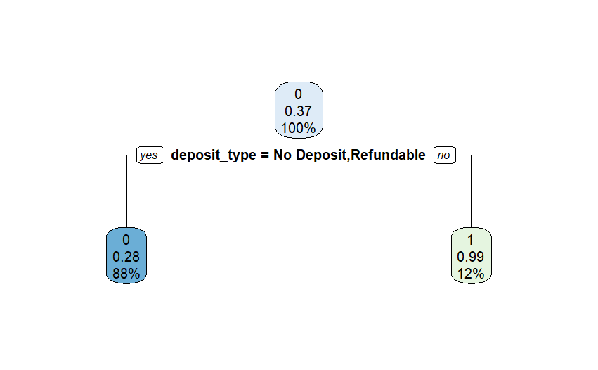

```r
training_model<-rpart(is_canceled~.,
                      data=training_1,
                      method="class",
                      control=rpart.control(cp=0.03))

rpart.plot(training_model)
```

Accuracy of the model

```r
test$ct_pred_prob<-predict(training_model,test)[,2]
test$ct_pred_class<-predict(training_model,test,type="class")


table(test$is_canceled==test$ct_pred_class)
```

```
FALSE  TRUE
 8940 26876
```

k-cross validation

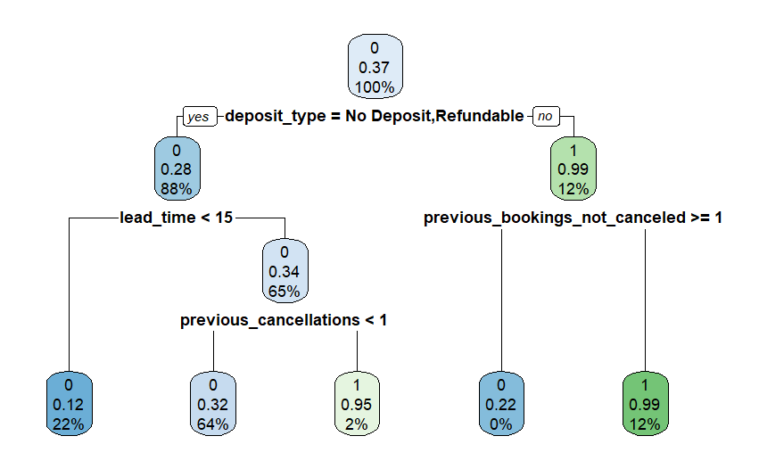

```r
set.seed(1)   # set a random seed
full_tree<-rpart(is_canceled~.,
                     data=training_1,
                     method="class",
                     control=rpart.control(cp=0, maxdepth = 3))

rpart.plot(full_tree)
```

```r
printcp(full_tree)   # xerror, xstd - cross validation results
```

```
Classification tree:
rpart(formula = is_canceled ~ ., data = training_1, method = "class",
    control = rpart.control(cp = 0, maxdepth = 3))

Variables actually used in tree construction:
[1] deposit_type                   lead_time
[3] previous_bookings_not_canceled previous_cancellations

Root node error: 30949/83572 = 0.37033

n= 83572

          CP nsplit rel error  xerror      xstd
1 0.32530938      0   1.00000 1.00000 0.0045106
2 0.02200394      1   0.67469 0.67469 0.0040439
3 0.00016156      3   0.63068 0.65608 0.0040060
4 0.00000000      4   0.63052 0.65582 0.0040055
```

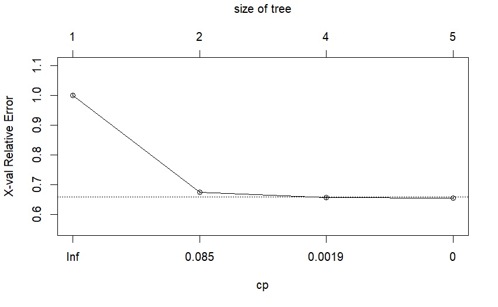

```r
plotcp(full_tree)
```

Hem d’escollir un valor de cp que minimitzi els errors del cross-validation.

```r
min_xerror<-full_tree$cptable[which.min(full_tree$cptable[,"xerror"]),]
min_xerror
```

```
         CP      nsplit   rel error      xerror        xstd
0.000000000 4.000000000 0.630521180 0.655820867 0.004005484
```

poda d’arbre amb el minim cp

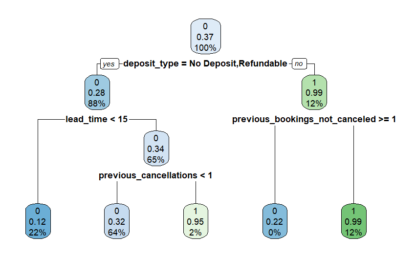

```r
min_xerror_tree<-prune(full_tree, cp=min_xerror[1])
rpart.plot(min_xerror_tree)
```

Accuracy del arbre podat

```r
bp_tree<-min_xerror_tree
test$ct_bp_pred_prob<-predict(bp_tree,test)[,2]
test$ct_bp_pred_class=ifelse(test$ct_bp_pred_prob>0.5,"Yes","No")

table(test$ct_bp_pred_class,test$is_canceled, dnn=c("predicted","actual"))
```

```
         actual
predicted     0     1
      No  22486  8309
      Yes    57  4964
```

```r
(22486+4964)/nrow(test)
```

```
[1] 0.7663958
```

El acuracy ha empitjorat ho intentarem amb un random forest